# 04_sequencer_comparison

Author

Hugo Maruyama

Published

March 6, 2026

## Introduction

In this module, a comprehensive quantitative comparison is performed between the Illumina MiSeq and Oxford Nanopore Technologies (ONT) platforms. The analysis focuses on evaluating the correlation of taxonomic abundances across various hierarchical levels and identifying potential platform-specific biases in microbial community characterization.

## Environment Setup

Necessary libraries for data visualization (`ggplot2`, `patchwork`, `ggtext`), table generation (`gt`), and data export (`writexl`) are loaded.

```r
library(tidyverse)
library(ggtext)
library(patchwork)
library(gt)
library(writexl)
library(knitr)
```

## Configuration

Parameters for highlighting top abundant taxa are defined to ensure visual clarity in the comparative plots.

```r
# Number of top abundant taxa to highlight in figures
top_n_to_highlight <- 15

# Ensure output directories exist
if (!dir.exists("figures")) dir.create("figures")
if (!dir.exists("tables")) dir.create("tables")
```

## Data Integration and Refinement

Harmonized datasets are imported and platform-specific nomenclature refinements are applied. For ecological clarity, genus and species names are combined, while maintaining specific nomenclature for candidate taxa (e.g., Patescibacteria/TM7).

```r
# Load processed data objects
illumina_processed <- readRDS("processed_data/illumina_processed.rds")
nanopore_processed <- readRDS("processed_data/nanopore_processed.rds")

# Refine taxonomic labels for clarity
# Illumina data refinement
illumina_processed <- illumina_processed %>%
  dplyr::mutate(
    species = dplyr::if_else(
      !is.na(genus) & !is.na(species),
      stringr::str_c(genus, species, sep = " "),
      species
    )
  )

# Nanopore data refinement with special handling for TM7
nanopore_processed <- nanopore_processed %>%
  dplyr::mutate(
    species = dplyr::if_else(
      !is.na(genus) & !is.na(species) & !stringr::str_detect(species, "TM7") & !str_starts(species, "Candidatus"),
      stringr::str_c(genus, species, sep = " "),
      species
    )
  )

# Filter for taxa meeting a minimum abundance threshold (0.1%)
abundance_threshold <- 0.1
illumina_filtered <- illumina_processed %>%
  dplyr::filter(if_any(where(is.numeric), ~ .x >= abundance_threshold))
nanopore_filtered <- nanopore_processed %>%
  dplyr::filter(if_any(where(is.numeric), ~ .x >= abundance_threshold))

# Reshape data to long format for comparative analysis
illumina_long <- illumina_filtered %>%
  tidyr::pivot_longer(cols = c(AP, BP, AS, BS), names_to = "Sample", values_to = "Abundance")

nanopore_long <- nanopore_filtered %>%
  tidyr::pivot_longer(cols = c(AP, BP, AS, BS), names_to = "Sample", values_to = "Abundance")
```

## Quantitative Correlation Analysis

The concordance between the two platforms is evaluated by calculating Spearman’s rank correlation across multiple taxonomic levels.

```r
tax_levels_to_analyze <- c("phylum", "family", "genus", "species")
correlation_summary_table <- tibble()
tableau_20_colors <- c(
  "#1f77b4", "#ff7f0e", "#2ca02c", "#d62728", "#9467bd",
  "#8c564b", "#e377c2", "#7f7f7f", "#bcbd22", "#17becf",
  "#aec7e8", "#ffbb78", "#98df8a", "#ff9896", "#c5b0d5",
  "#c49c94", "#f7b6d2", "#c7c7c7", "#dbdb8d", "#9edae5"
)

for (tax_level in tax_levels_to_analyze) {
  # Aggregate and merge datasets
  illumina_agg <- illumina_long %>%
    dplyr::group_by(Sample, !!rlang::sym(tax_level)) %>%
    dplyr::summarise(Abundance = sum(Abundance), .groups = 'drop') %>%
    dplyr::filter(!is.na(!!rlang::sym(tax_level)))

  nanopore_agg <- nanopore_long %>%
    dplyr::group_by(Sample, !!rlang::sym(tax_level)) %>%
    dplyr::summarise(Abundance = sum(Abundance), .groups = 'drop') %>%
    dplyr::filter(!is.na(!!rlang::sym(tax_level)))

  merged_data <- dplyr::full_join(
    illumina_agg, nanopore_agg, by = c(tax_level, "Sample"),
    suffix = c("_illumina", "_nanopore")
  ) %>%
    replace(is.na(.), 0)

  assign(paste0("merged_data_", tax_level), merged_data)

  # Calculate Spearman's correlation
  cor_test <- cor.test(merged_data$Abundance_illumina, merged_data$Abundance_nanopore, method = "spearman")
  correlation_summary_table <- dplyr::bind_rows(correlation_summary_table, tibble(
    Taxonomic_Level = tax_level,
    Spearman_rho = cor_test$estimate,
    p_value = cor_test$p.value
  ))

  # Generate Scatter Plots
  top_taxa <- merged_data %>%
    dplyr::group_by(!!rlang::sym(tax_level)) %>%
    dplyr::summarise(mean_abundance = mean(Abundance_illumina + Abundance_nanopore)) %>%
    dplyr::slice_max(order_by = mean_abundance, n = top_n_to_highlight) %>%
    dplyr::pull(!!rlang::sym(tax_level))

  merged_data_for_plot <- merged_data %>%
    dplyr::mutate(
      Taxon_Color = factor(dplyr::if_else(!!rlang::sym(tax_level) %in% top_taxa, !!rlang::sym(tax_level), "Other"),
                           levels = c(top_taxa, "Other"))
    )

  color_values <- setNames(tableau_20_colors[1:length(top_taxa)], top_taxa)
  color_values["Other"] <- "grey70"
  markdown_labels <- setNames(paste0("*", top_taxa, "*"), top_taxa)
  markdown_labels["Other"] <- "Other"

  correlation_plot <- ggplot(merged_data_for_plot, aes(x = Abundance_illumina, y = Abundance_nanopore)) +
    geom_abline(intercept = 1, slope = 1, color = "red", linetype = "dashed") +
    geom_abline(intercept = -1, slope = 1, color = "red", linetype = "dashed") +
    geom_abline(intercept = 0, slope = 1, color = "black", linetype = "dashed") +
    geom_point(aes(color = Taxon_Color, size = (Abundance_illumina + Abundance_nanopore) / 2), alpha = 0.7) +
    scale_x_continuous(trans = 'log10', labels = scales::label_number()) +
    scale_y_continuous(trans = 'log10', labels = scales::label_number()) +
    scale_color_manual(name = stringr::str_to_title(tax_level), values = color_values, labels = markdown_labels) +
    labs(x = "Illumina abundance (%)", y = "ONT abundance (%)", size = "Average abundance (%)") +
    theme_bw(base_size = 14) +
    theme(legend.text = ggtext::element_markdown(size = 10), legend.key.height = unit(0.4, "cm")) +
    annotate("text", x = min(merged_data_for_plot$Abundance_illumina[merged_data_for_plot$Abundance_illumina > 0]),
             y = max(merged_data_for_plot$Abundance_nanopore), label = paste("ρ =", round(cor_test$estimate, 3)),
             hjust = 0, vjust = 1, size = 5) +
    guides(color = guide_legend(ncol = 1, title.position = "top"), size = "none")

  assign(paste0("correlation_plot_", tax_level), correlation_plot)
  ggsave(filename = paste0("figures/correlation_plot_", tax_level, ".png"), plot = correlation_plot, width = 8, height = 6)
}

# Generate and export Table 2: Spearman Rank Correlation Summary
correlation_summary_gt <- correlation_summary_table %>%
  dplyr::mutate(
    Taxonomic_Level = stringr::str_to_title(Taxonomic_Level),
    Spearman_rho = round(Spearman_rho, 3),
    p_value = format.pval(p_value, digits = 3, eps = 0.001)
  ) %>%
  gt() %>%
  tab_header(
    title = "Table 2: Spearman Rank Correlation Coefficients across Taxonomic Levels"
  ) %>%
  cols_label(
    Taxonomic_Level = "Taxonomic Level",
    Spearman_rho = "Spearman's ρ",
    p_value = "p-value"
  ) %>%
  cols_align(
    align = "center",
    columns = everything()
  ) %>%
  tab_options(
    column_labels.font.weight = "bold",
    table_body.hlines.style = "none"
  )

gtsave(correlation_summary_gt, "tables/Table2_correlation_summary.png")
gtsave(correlation_summary_gt, "tables/Table2_correlation_summary.rtf")

# Export Supplementary Table S1
write_xlsx(list("phylum" = merged_data_phylum, "family" = merged_data_family, "genus" = merged_data_genus, "species" = merged_data_species),
           "tables/Supplementary_Table_S1.xlsx")
```

## Comparative Visualization (Figure 2 & S1)

Correlation plots are combined into multipanel figures for comparative assessment. Figure 2 presents the phylum and genus levels, while Supplementary Figure S1 provides the family and species levels.

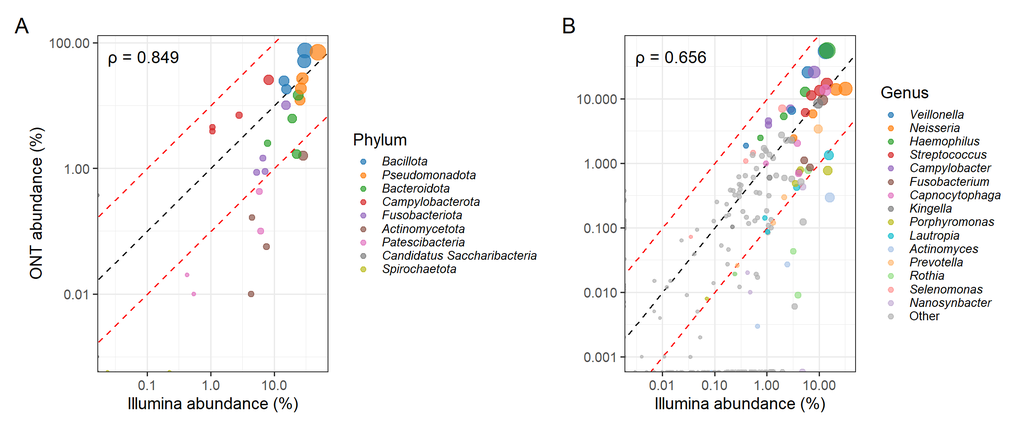

```r
# Main Figure 2: Phylum and Genus
figure_2 <- correlation_plot_phylum + correlation_plot_genus +
  plot_layout(axis_titles = 'collect_y') +
  plot_annotation(tag_levels = 'A') &
  theme(plot.tag = element_text(size = 18))

ggsave("figures/fig2_correlation_comparison.png", figure_2, width = 12, height = 5)

# Supplementary Figure S1: Family and Species
supplementary_figure_s1 <- correlation_plot_family + correlation_plot_species +
  plot_layout(axis_titles = 'collect_y') +
  plot_annotation(tag_levels = 'A') &
  theme(plot.tag = element_text(size = 18))

ggsave("figures/Supplementary_Figure_S1.png", supplementary_figure_s1, width = 12, height = 5)

# Display Figure 2 in the document
figure_2
```

## Taxonomic Bias and Platform-Specific Enrichment

Taxa that exhibit significant discrepancies between the two platforms are identified by calculating the Log2 Fold Change (LFC).

```r
merged_long_data <- dplyr::full_join(
  illumina_long, nanopore_long,
  by = c("kingdom", "phylum", "class", "order", "family", "genus", "species", "Sample"),
  suffix = c("_illumina", "_nanopore")
) %>%
  dplyr::mutate(dplyr::across(c(Abundance_illumina, Abundance_nanopore), ~ tidyr::replace_na(., 0)))

for (tax_level in tax_levels_to_analyze) {
  summary_table <- merged_long_data %>%
    dplyr::group_by(!!rlang::sym(tax_level), Sample) %>%
    dplyr::summarise(Abundance_illumina = sum(Abundance_illumina), Abundance_nanopore = sum(Abundance_nanopore), .groups = 'drop') %>%
    dplyr::filter(!is.na(!!rlang::sym(tax_level))) %>%
    dplyr::group_by(!!rlang::sym(tax_level)) %>%
    dplyr::filter(n() >= 3) %>%
    dplyr::summarise(
      correlation = cor(Abundance_illumina, Abundance_nanopore, method = "spearman"),
      mean_illumina = mean(Abundance_illumina), sd_illumina = sd(Abundance_illumina),
      mean_nanopore = mean(Abundance_nanopore), sd_nanopore = sd(Abundance_nanopore),
      .groups = 'drop'
    ) %>%
    dplyr::mutate(log2_fold_change = log2((mean_nanopore + 0.001) / (mean_illumina + 0.001))) %>%
    dplyr::arrange(desc(abs(log2_fold_change)))

  assign(paste0("per_taxon_summary_", tax_level), summary_table)
}
```

## MA Plots for Bias Visualization (Supp Fig S2)

MA plots (M = log ratio, A = average abundance) visualize the platform-specific bias relative to the overall abundance of each taxon.

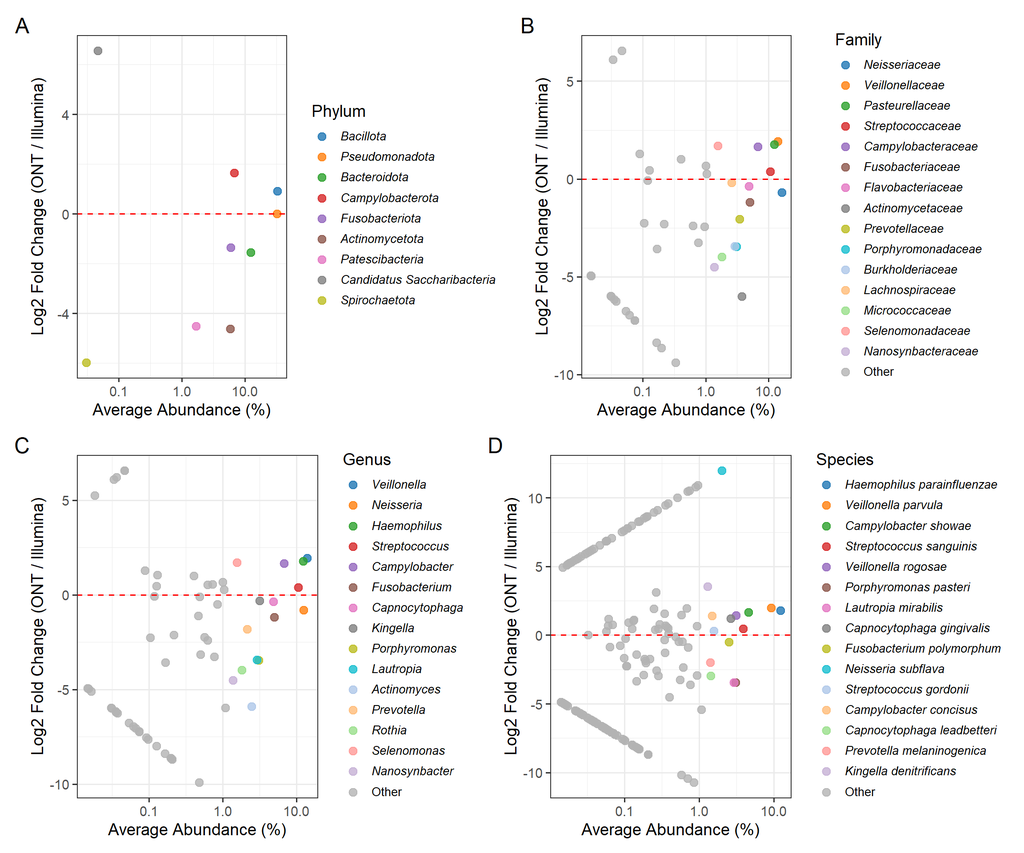

```r
for (tax_level in tax_levels_to_analyze) {
  ma_data <- get(paste0("per_taxon_summary_", tax_level)) %>%
    mutate(average_abundance = (mean_illumina + mean_nanopore) / 2)
  top_taxa <- ma_data %>% slice_max(order_by = average_abundance, n = top_n_to_highlight) %>% pull(!!rlang::sym(tax_level))

  ma_plot <- ggplot(ma_data %>% mutate(Taxon_Color = factor(if_else(!!rlang::sym(tax_level) %in% top_taxa, !!rlang::sym(tax_level), "Other"), levels = c(top_taxa, "Other"))),
                    aes(x = average_abundance, y = log2_fold_change)) +
    geom_point(aes(color = Taxon_Color), size = 3, alpha = 0.8) +
    geom_hline(yintercept = 0, linetype = "dashed", color = "red") +
    scale_x_log10(labels = scales::label_number()) +
    scale_color_manual(name = stringr::str_to_title(tax_level), values = setNames(c(tableau_20_colors[1:length(top_taxa)], "grey70"), c(top_taxa, "Other")),
                       labels = setNames(c(paste0("*", top_taxa, "*"), "Other"), c(top_taxa, "Other"))) +
    labs(x = "Average Abundance (%)", y = "Log2 Fold Change (ONT / Illumina)") +
    theme_bw(base_size = 14) + theme(legend.text = ggtext::element_markdown(size = 10))

  assign(paste0("ma_plot_", tax_level), ma_plot)
}

supplementary_figure_s2 <- (ma_plot_phylum + ma_plot_family) / (ma_plot_genus + ma_plot_species) +
  plot_annotation(tag_levels = 'A') & theme(plot.tag = element_text(size = 18))
ggsave("figures/Supplementary_Figure_S2.png", supplementary_figure_s2, width = 12, height = 10)
supplementary_figure_s2
```

**Note:** The MA plots above correspond to **Supplementary Figure S2** in the manuscript (Exported as `Supplementary_Figure_S2.png`).

## Hierarchical Summary of Biases (Table 3)

```r
genus_phylum_map <- illumina_processed %>% dplyr::select(phylum, genus) %>% dplyr::distinct() %>% dplyr::filter(!is.na(genus) & !is.na(phylum))
phyla_of_interest <- c("Bacteroidota", "Pseudomonadota", "Actinomycetota", "Bacillota", "Patescibacteria", "Campylobacterota", "Fusobacteriota")
genera_of_interest <- c("Veillonella", "Haemophilus", "Campylobacter", "Actinomyces", "Porphyromonas", "Lautropia", "Prevotella", "Rothia", "Selenomonas", "Nanosynbacter", "Corynebacterium", "Pseudoleptotrichia", "Fusobacterium")

hierarchical_table_data <- dplyr::bind_rows(
  per_taxon_summary_phylum %>% dplyr::filter(phylum %in% phyla_of_interest) %>% dplyr::mutate(is_phylum = TRUE),
  per_taxon_summary_genus %>% dplyr::filter(genus %in% genera_of_interest) %>% dplyr::left_join(genus_phylum_map, by = "genus") %>% dplyr::mutate(is_phylum = FALSE)
) %>%
  dplyr::mutate(Phylum_Group = coalesce(phylum, genus),
                illumina_display = paste0(round(mean_illumina, 1), " ± ", round(sd_illumina, 1)),
                nanopore_display = paste0(round(mean_nanopore, 1), " ± ", round(sd_nanopore, 1)),
                Taxon = if_else(is_phylum, paste0("***", phylum, "***"), paste0("└─ *", genus, "*"))) %>%
  dplyr::arrange(Phylum_Group, desc(is_phylum), desc(mean_illumina))

hierarchical_bias_table_gt <- hierarchical_table_data %>%
  gt() %>%
  cols_hide(columns = c(Phylum_Group, is_phylum)) %>%
  fmt_markdown(columns = Taxon) %>%
  tab_style(style = cell_text(weight = "bold"), locations = cells_body(rows = is_phylum == TRUE)) %>%
  tab_header(title = "Table 3: Taxa with Significant Platform-Specific Bias") %>%
  cols_label(Taxon = "Taxon", illumina_display = "Illumina", nanopore_display = "ONT") %>%
  tab_spanner(label = "Mean Abundance ± SD (%)", columns = c(illumina_display, nanopore_display)) %>%
  cols_align(align = "left", columns = Taxon) %>%
  tab_options(column_labels.font.weight = "bold", table_body.hlines.style = "none")

gtsave(hierarchical_bias_table_gt, "tables/Table3_hierarchical_bias_table.png")
gtsave(hierarchical_bias_table_gt, "tables/Table3_hierarchical_bias_table.rtf")
hierarchical_bias_table_gt
```

| phylum | correlation | mean_illumina | sd_illumina | mean_nanopore | sd_nanopore | log2_fold_change | genus | Mean Abundance ± SD (%) Illumina | Mean Abundance ± SD (%) ONT | Taxon |  |
| --- | --- | --- | --- | --- | --- | --- | --- | --- | --- | --- | --- |
| Actinomycetota | 0.8 | 11.25250 | 11.6608678 | 0.45575 | 0.7602361 | -4.6228252 | NA | 11.3 ± 11.7 | 0.5 ± 0.8 |  | *Actinomycetota* |
| Actinomycetota | 1.0 | 4.83700 | 7.6019546 | 0.08075 | 0.1420150 | -5.8870482 | Actinomyces | 4.8 ± 7.6 | 0.1 ± 0.1 | └─ *Actinomyces* |  |
| Actinomycetota | 0.4 | 3.40675 | 2.4498177 | 0.21550 | 0.3839319 | -3.9763806 | Rothia | 3.4 ± 2.4 | 0.2 ± 0.4 | └─ *Rothia* |  |
| Actinomycetota | NA | 0.33075 | 0.5595876 | 0.00000 | 0.0000000 | -8.3739527 | Corynebacterium | 0.3 ± 0.6 | 0 ± 0 | └─ *Corynebacterium* |  |
| Bacillota | 0.8 | 22.41150 | 8.7060999 | 42.45300 | 26.2833035 | 0.9215969 | NA | 22.4 ± 8.7 | 42.5 ± 26.3 | *Bacillota* |  |
| Bacillota | 1.0 | 5.77125 | 5.7237384 | 22.10100 | 23.6888701 | 1.9369712 | Veillonella | 5.8 ± 5.7 | 22.1 ± 23.7 | └─ *Veillonella* |  |
| Bacillota | 1.0 | 0.73575 | 0.8506544 | 2.39775 | 3.1138484 | 1.7030357 | Selenomonas | 0.7 ± 0.9 | 2.4 ± 3.1 | └─ *Selenomonas* |  |
| Bacteroidota | 0.4 | 18.38925 | 7.2981041 | 6.27400 | 5.9099111 | -1.5512537 | NA | 18.4 ± 7.3 | 6.3 ± 5.9 | *Bacteroidota* |  |
| Bacteroidota | 0.8 | 5.64975 | 6.2646661 | 0.51575 | 0.3663563 | -3.4509040 | Porphyromonas | 5.6 ± 6.3 | 0.5 ± 0.4 | └─ *Porphyromonas* |  |
| Bacteroidota | 1.0 | 3.34625 | 4.2670406 | 0.95525 | 1.6197404 | -1.8075166 | Prevotella | 3.3 ± 4.3 | 1 ± 1.6 | └─ *Prevotella* |  |
| Campylobacterota | 1.0 | 3.27125 | 3.3451701 | 10.27600 | 10.3697379 | 1.6510643 | NA | 3.3 ± 3.3 | 10.3 ± 10.4 | *Campylobacterota* |  |
| Campylobacterota | 1.0 | 3.27125 | 3.3451701 | 10.27600 | 10.3697379 | 1.6510643 | Campylobacter | 3.3 ± 3.3 | 10.3 ± 10.4 | └─ *Campylobacter* |  |
| Fusobacteriota | 0.8 | 8.55050 | 4.4712275 | 3.34375 | 4.5404122 | -1.3542791 | NA | 8.6 ± 4.5 | 3.3 ± 4.5 | *Fusobacteriota* |  |
| Fusobacteriota | 0.8 | 6.94525 | 3.3262705 | 3.04800 | 4.3023120 | -1.1878982 | Fusobacterium | 6.9 ± 3.3 | 3 ± 4.3 | └─ *Fusobacterium* |  |
| Fusobacteriota | NA | 0.96175 | 0.7024611 | 0.00000 | 0.0000000 | -9.9110174 | Pseudoleptotrichia | 1 ± 0.7 | 0 ± 0 | └─ *Pseudoleptotrichia* |  |
| Patescibacteria | 0.6 | 3.22200 | 3.1600759 | 0.13950 | 0.1965053 | -4.5197622 | NA | 3.2 ± 3.2 | 0.1 ± 0.2 | *Patescibacteria* |  |
| Patescibacteria | 0.2 | 2.64050 | 2.5292361 | 0.11450 | 0.2091594 | -4.5153927 | Nanosynbacter | 2.6 ± 2.5 | 0.1 ± 0.2 | └─ *Nanosynbacter* |  |
| Pseudomonadota | 1.0 | 32.06925 | 11.0170689 | 32.32325 | 26.6538723 | 0.0113813 | NA | 32.1 ± 11 | 32.3 ± 26.7 | *Pseudomonadota* |  |
| Pseudomonadota | 1.0 | 5.63375 | 6.0855485 | 19.20150 | 24.9836444 | 1.7688706 | Haemophilus | 5.6 ± 6.1 | 19.2 ± 25 | └─ *Haemophilus* |  |
| Pseudomonadota | 0.8 | 5.32100 | 6.9927326 | 0.49200 | 0.5709623 | -3.4323090 | Lautropia | 5.3 ± 7 | 0.5 ± 0.6 | └─ *Lautropia* |  |

**Note:** This table corresponds to **Table 3** in the main manuscript (Exported as `Table3_hierarchical_bias_table.png`). Detailed metrics for all hierarchical levels are available in `Supplementary_Table_S2.xlsx`.

## Data Archival

The detailed bias analysis results are exported to a multi-sheet Excel workbook for further reference.

```r
writexl::write_xlsx(list("Phylum" = per_taxon_summary_phylum, "Family" = per_taxon_summary_family,
                         "Genus"  = per_taxon_summary_genus, "Species" = per_taxon_summary_species),
                    "tables/Supplementary_Table_S2.xlsx")
```

The sequencer comparison demonstrates high overall correlation but reveals critical platform-specific biases for certain oral taxa, which must be considered when interpreting microbiome profiles.